# ACST8095 Assignment

Name: Ngoc Tuyet Trinh

Date: 2024-10-20

To ensure the reproducibility, first clear the current environment and add set.seed (10)

```r
rm(list = ls())
set.seed(10)
```

Question a)

First, I load the required library and import the dataset

```r
library(readr)
library(ggplot2)
library(rpart)
library(rpart.plot)
library(caret)
Assg <- read_csv("CaseStudyData.csv")
```

There are 180000 values and 7 columns.Gender is a categorical variable. Some basic statistics are provided:

```r
str(Assg)
```

```
## spc_tbl_ [180,000 x 7] (S3: spec_tbl_df/tbl_df/tbl/data.frame)
##  $ Counts  : num [1:180000] 0 0 0 0 0 0 0 0 0 0 ...
##  $ gender  : chr [1:180000] "female" "male" "male" "male" ...
##  $ distance: num [1:180000] 32 8 10 15 36 36 15 14 6 11 ...
##  $ weight  : num [1:180000] 1385 1607 1299 3288 1948 ...
##  $ age     : num [1:180000] 27 63 62 32 27 28 32 59 61 66 ...
##  $ carage  : num [1:180000] 21 9 9 9 10 6 16 25 25 10 ...
##  $ exposure: num [1:180000] 0.909 0.938 0.89 0.82 0.927 ...
##  - attr(*, "spec")=
##   .. cols(
##   ..   Counts = col_double(),
##   ..   gender = col_character(),
##   ..   distance = col_double(),
##   ..   weight = col_double(),
##   ..   age = col_double(),
##   ..   carage = col_double(),
##   ..   exposure = col_double()
##   .. )
##  - attr(*, "problems")=<externalptr>
```

```r
summary(Assg)
```

```
##      Counts          gender             distance      weight
##  Min.   :0.0000   Length:180000      Min.   : 2   Min.   : 653
##  1st Qu.:0.0000   Class :character   1st Qu.:13   1st Qu.:1444
##  Median :0.0000   Mode  :character   Median :19   Median :1914
##  Mean   :0.1223                      Mean   :21   Mean   :2017
##  3rd Qu.:0.0000                      3rd Qu.:28   3rd Qu.:2523
##  Max.   :4.0000                      Max.   :50   Max.   :3996
##       age            carage         exposure
##  Min.   :19.00   Min.   : 2.00   Min.   :0.8000
##  1st Qu.:34.00   1st Qu.: 9.00   1st Qu.:0.8500
##  Median :55.00   Median :18.00   Median :0.8998
##  Mean   :49.27   Mean   :16.45   Mean   :0.8998
##  3rd Qu.:64.00   3rd Qu.:24.00   3rd Qu.:0.9497
##  Max.   :77.00   Max.   :29.00   Max.   :1.0000
```

There is no missing value

```r
sapply(Assg, function(x) sum(is.na(x)))
```

```
##   Counts   gender distance   weight      age   carage exposure
##        0        0        0        0        0        0        0
```

Plot histogram for the numerical attributes

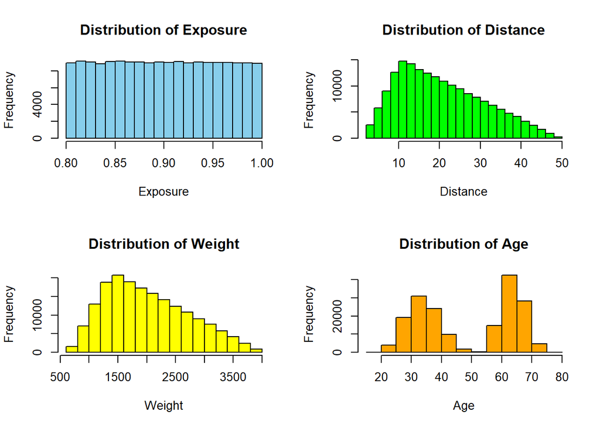

```r
par(mfrow = c(2,2))
hist(Assg$exposure, main = "Distribution of Exposure", xlab = "Exposure", col = "skyblue")
hist(Assg$distance, main = "Distribution of Distance", xlab = "Distance", col = "green")
hist(Assg$weight, main = "Distribution of Weight", xlab = "Weight", col = "yellow")
hist(Assg$age, main = "Distribution of Age", xlab = "Age", col = "orange")
```

Plot pie chart for categorical attribute “gender”

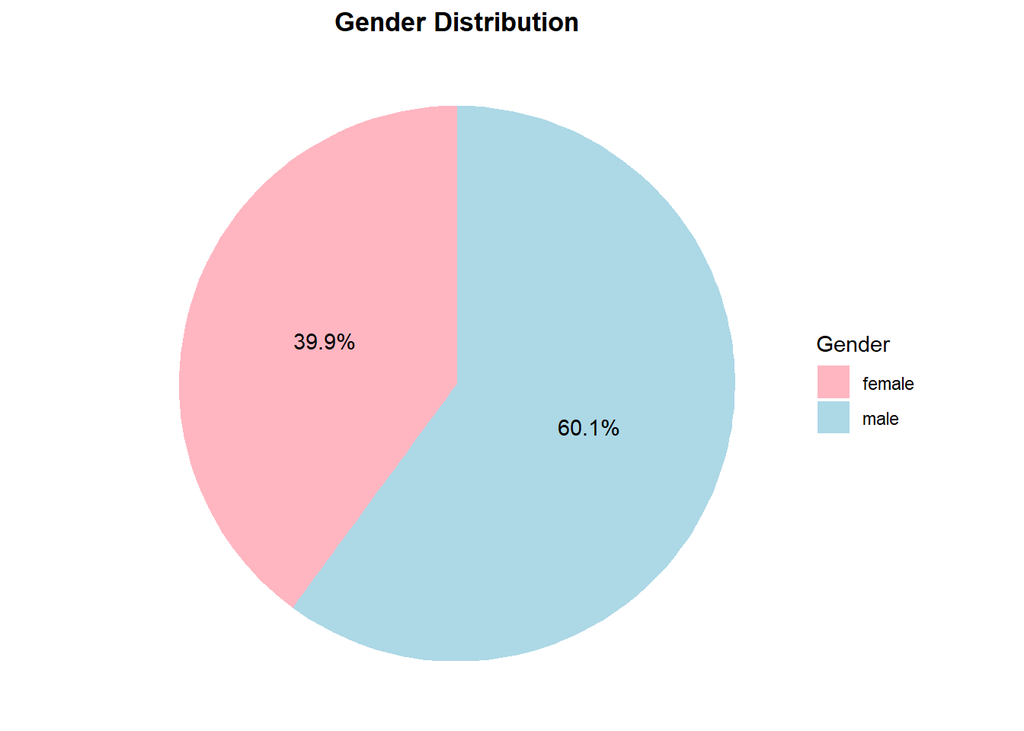

```r
par(mfrow = c(1, 1))
Assg$gender <- as.factor(Assg$gender)
gender_plot <- as.data.frame(table(Assg$gender))
colnames(gender_plot) <- c("Gender", "Frequency")
gender_plot$Percentage <- round((gender_plot$Frequency / sum(gender_plot$Frequency)) * 100, 1)
ggplot(gender_plot, aes(x = "", y = Frequency, fill = Gender)) +
  geom_bar(width = 1, stat = "identity") +
  coord_polar("y") +
  labs(title = "Gender Distribution") +
  theme_void() +
  geom_text(aes(label = paste0(Percentage, "%")),
            position = position_stack(vjust = 0.5)) +
  scale_fill_manual(values = c("female" = "lightpink", "male" = "lightblue")) +
  theme(plot.title = element_text(hjust = 0.5, face = "bold"))
```

Question b)

First, I fit the glm() for ln(λ) considering all the linear terms, quadratic terms (excluding x5) and mixed terms (excluding x5) as required in the question.

```r
model <- glm(Counts ~ weight + distance + age + carage + gender+
              I(weight^2) + I(distance^2) + I(age^2) + I(carage^2)+
              weight*distance + weight*age + weight*carage +
              distance*age + distance*carage +
              age*carage,
              data = Assg, family = poisson(), offset = log(exposure))
summary(model)
```

```
##
## Call:
## glm(formula = Counts ~ weight + distance + age + carage + gender +
##     I(weight^2) + I(distance^2) + I(age^2) + I(carage^2) + weight *
##     distance + weight * age + weight * carage + distance * age +
##     distance * carage + age * carage, family = poisson(), data = Assg,
##     offset = log(exposure))
##
## Coefficients:
##                   Estimate Std. Error z value Pr(>|z|)
## (Intercept)     -6.031e+00  2.097e-01 -28.764  < 2e-16 ***
## weight           2.193e-04  7.260e-05   3.021  0.00252 **
## distance        -1.240e-03  4.562e-03  -0.272  0.78569
## age              5.090e-02  5.623e-03   9.052  < 2e-16 ***
## carage           1.378e-01  9.457e-03  14.574  < 2e-16 ***
## gendermale       2.776e-03  1.377e-02   0.202  0.84025
## I(weight^2)     -8.194e-09  1.180e-08  -0.694  0.48759
## I(distance^2)    1.106e-04  5.657e-05   1.956  0.05048 .
## I(age^2)         7.418e-05  5.106e-05   1.453  0.14622
## I(carage^2)      1.205e-04  2.289e-04   0.526  0.59869
## weight:distance -6.008e-07  8.696e-07  -0.691  0.48966
## weight:age      -3.633e-07  6.298e-07  -0.577  0.56404
## weight:carage    1.404e-06  1.316e-06   1.067  0.28588
## distance:age     1.934e-05  4.368e-05   0.443  0.65802
## distance:carage -1.538e-05  9.081e-05  -0.169  0.86554
## age:carage      -1.934e-03  6.922e-05 -27.937  < 2e-16 ***
## ---
## Signif. codes:  0 '***' 0.001 '**' 0.01 '*' 0.05 '.' 0.1 ' ' 1
##
## (Dispersion parameter for poisson family taken to be 1)
##
##     Null deviance: 96974  on 179999  degrees of freedom
## Residual deviance: 91801  on 179984  degrees of freedom
## AIC: 133617
##
## Number of Fisher Scoring iterations: 6
```

I conduct backward selection method via step() to select the best model

```r
set.seed(10)
model_new<- step(model, direction ="backward", trace = 0)
model_new
```

```
##
## Call:  glm(formula = Counts ~ weight + age + carage + I(distance^2) +
##     I(age^2) + age:carage, family = poisson(), data = Assg, offset = log(exposure))
##
## Coefficients:
##   (Intercept)         weight            age         carage  I(distance^2)
##    -6.042e+00      1.761e-04      5.060e-02      1.446e-01      7.610e-05
##      I(age^2)     age:carage
##     7.438e-05     -1.938e-03
##
## Degrees of Freedom: 179999 Total (i.e. Null);  179993 Residual
## Null Deviance:       96970
## Residual Deviance: 91800     AIC: 133600
```

Given the benchmark, the λ = 0.01716377

```r
lambda<-predict(model_new, list(weight = 1500, distance = 15, age = 25, carage = 4, gender ="male", exposure = 1), type="response")
lambda
```

```
##          1
## 0.01716377
```

Plotting λ vs age (x3)

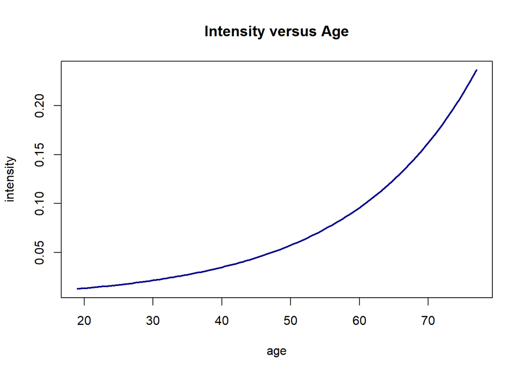

```r
xage<-seq(min(Assg$age),max(Assg$age),0.5)
y<-predict(model_new, list(age=xage,
                                 weight=rep(1500,length(xage)),
                                 distance=rep(15,length(xage)),
                                 carage=rep(4,length(xage)),
                                 gender=rep("male",length(xage)),
                                 exposure=rep(1,length(xage))), type="response")

plot(xage,y,type = "l",main = "Intensity versus Age", xlab="age",ylab="intensity", col = "darkblue",lwd = 2)
```

Question c)

Plot the Total within sum of squares versus number of clusters. As observed, the optimal number of cluster is 4

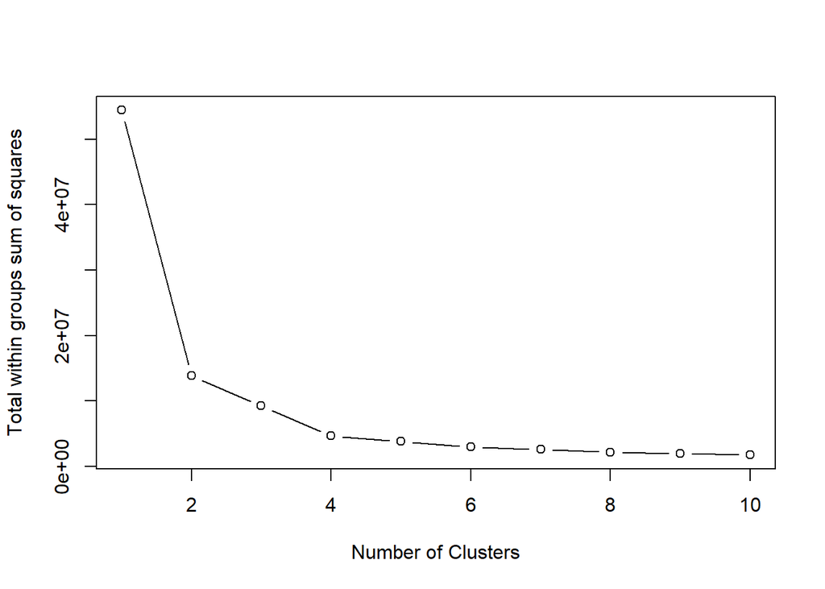

```r
x <- data.frame(x3 = Assg$age, x4 = Assg$carage)
wss <- c()
for (i in 1:10) wss[i] <- sum(kmeans(x, i, nstart=15)$withinss)
plot(1:10, wss, type="b", xlab="Number of Clusters", ylab="Total within groups sum of squares")
```

Assign the cluster label to the dataset

```r
x3x4 <- kmeans(x,4,nstart = 15)
Assg$cluster <- as.factor(x3x4$cluster)
```

Plot

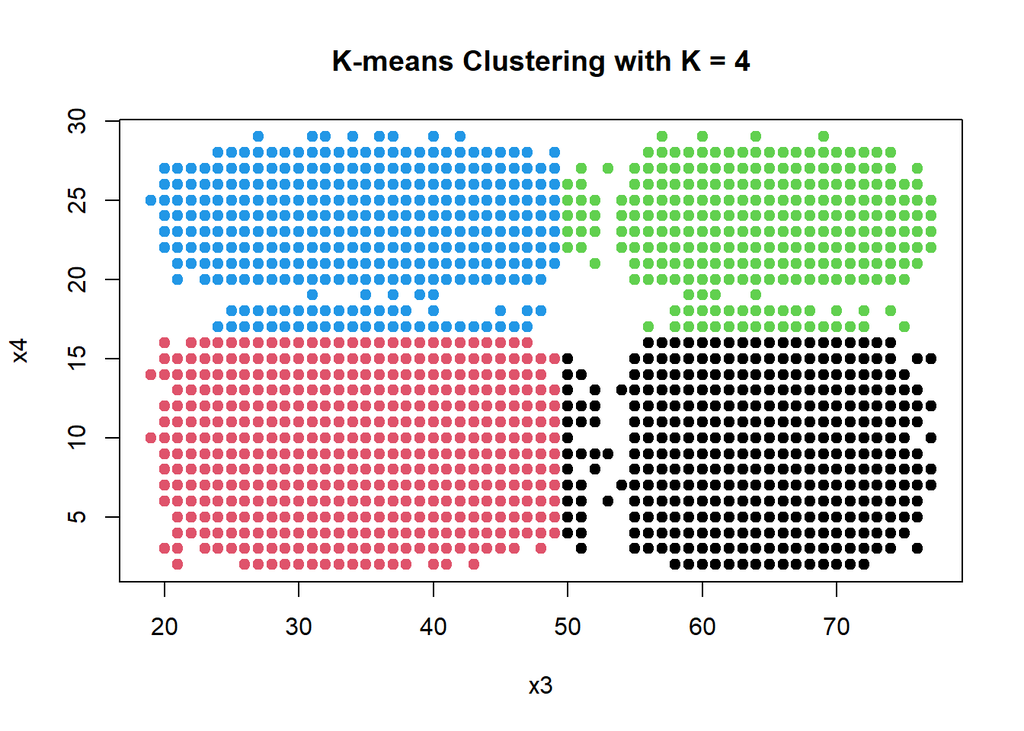

```r
plot(x,col=Assg$cluster,cex = 1.5,pch = 20, xlab = "x3", ylab = "x4",
     main = "K-means Clustering with K = 4", font.main = 2)
```

Question d)

Fit the glm() for ln(λ) considering all the linear and mixed terms

```r
model2 <- glm(Counts ~ weight + distance + age + carage + gender + cluster +
                    weight:distance + weight:age + weight*carage + weight*gender + weight*cluster +
                    distance*age + distance*carage + distance*gender + distance*cluster +
                    age*carage + age*gender + age*cluster +
                    carage*gender + carage*cluster +
                    gender*cluster,
                  data = Assg, family = poisson(),offset = log(exposure))
summary(model2)
```

```
##
## Call:
## glm(formula = Counts ~ weight + distance + age + carage + gender +
##     cluster + weight:distance + weight:age + weight * carage +
##     weight * gender + weight * cluster + distance * age + distance *
##     carage + distance * gender + distance * cluster + age * carage +
##     age * gender + age * cluster + carage * gender + carage *
##     cluster + gender * cluster, family = poisson(), data = Assg,
##     offset = log(exposure))
##
## Coefficients:
##                       Estimate Std. Error z value Pr(>|z|)
## (Intercept)         -4.017e+00  6.530e-01  -6.152 7.67e-10 ***
## weight               3.730e-04  1.459e-04   2.556   0.0106 *
## distance             1.428e-02  1.028e-02   1.390   0.1646
## age                  2.463e-02  9.880e-03   2.493   0.0127 *
## carage               5.350e-02  5.143e-02   1.040   0.2983
## gendermale           5.225e-02  2.222e-01   0.235   0.8141
## cluster2             3.350e-01  4.192e-01   0.799   0.4242
## cluster3            -2.304e-01  8.029e-01  -0.287   0.7741
## cluster4             3.876e-01  4.296e-01   0.902   0.3670
## weight:distance     -5.791e-07  8.733e-07  -0.663   0.5073
## weight:age          -3.382e-06  2.127e-06  -1.590   0.1118
## weight:carage       -5.102e-07  4.431e-06  -0.115   0.9083
## weight:gendermale    2.388e-05  1.877e-05   1.273   0.2032
## weight:cluster2     -6.663e-05  7.551e-05  -0.882   0.3775
## weight:cluster3      4.378e-05  6.683e-05   0.655   0.5124
## weight:cluster4     -6.913e-05  9.303e-05  -0.743   0.4574
## distance:age        -9.560e-05  1.486e-04  -0.643   0.5201
## distance:carage     -2.280e-04  3.100e-04  -0.736   0.4619
## distance:gendermale -1.884e-03  1.307e-03  -1.442   0.1494
## distance:cluster2   -3.710e-03  5.280e-03  -0.703   0.4823
## distance:cluster3    3.539e-03  4.677e-03   0.757   0.4492
## distance:cluster4   -3.344e-04  6.515e-03  -0.051   0.9591
## age:carage          -5.452e-04  7.718e-04  -0.706   0.4800
## age:gendermale      -1.801e-03  3.190e-03  -0.565   0.5724
## age:cluster2        -2.764e-02  5.829e-03  -4.741 2.12e-06 ***
## age:cluster3        -9.401e-05  1.183e-02  -0.008   0.9937
## age:cluster4        -3.886e-03  1.175e-02  -0.331   0.7408
## carage:gendermale    5.881e-03  6.644e-03   0.885   0.3761
## carage:cluster2     -2.681e-02  2.577e-02  -1.041   0.2981
## carage:cluster3      6.029e-03  8.309e-03   0.726   0.4681
## carage:cluster4     -1.276e-02  2.516e-02  -0.507   0.6120
## gendermale:cluster2 -4.574e-02  1.133e-01  -0.404   0.6865
## gendermale:cluster3 -6.901e-02  1.003e-01  -0.688   0.4915
## gendermale:cluster4 -1.576e-01  1.396e-01  -1.129   0.2591
## ---
## Signif. codes:  0 '***' 0.001 '**' 0.01 '*' 0.05 '.' 0.1 ' ' 1
##
## (Dispersion parameter for poisson family taken to be 1)
##
##     Null deviance: 96974  on 179999  degrees of freedom
## Residual deviance: 91338  on 179966  degrees of freedom
## AIC: 133190
##
## Number of Fisher Scoring iterations: 6
```

Perform backward selection method to select the best model

```r
model_new2<- step(model2, direction ="backward", trace = 0)
model_new2
```

```
##
## Call:  glm(formula = Counts ~ weight + distance + age + carage + gender +
##     cluster + distance:gender + age:cluster, family = poisson(),
##     data = Assg, offset = log(exposure))
##
## Coefficients:
##         (Intercept)               weight             distance
##          -3.0674236            0.0001759            0.0046585
##                 age               carage           gendermale
##           0.0093299            0.0166915            0.0433579
##            cluster2             cluster3             cluster4
##          -0.1582888            0.5378466            0.3309167
## distance:gendermale         age:cluster2         age:cluster3
##          -0.0018978           -0.0277271           -0.0080096
##        age:cluster4
##          -0.0116754
##
## Degrees of Freedom: 179999 Total (i.e. Null);  179987 Residual
## Null Deviance:       96970
## Residual Deviance: 91350     AIC: 133200
```

Given benchmark in b), For cluster 1, λ = 0.08902562

```r
lambda2_1<-predict(model_new2, list(weight = 1500, distance = 15, age = 25, carage = 4, gender ="male",cluster = "1", exposure = 1), type="response")
lambda2_1
```

```
##          1
## 0.08902562
```

Given benchmark in b), For cluster 2, λ = 0.03799512

```r
lambda2_2<-predict(model_new2, list(weight = 1500, distance = 15, age = 25, carage = 4, gender ="male",cluster = "2", exposure = 1), type="response")
lambda2_2
```

```
##          1
## 0.03799512
```

Given benchmark in b), For cluster 3, λ = 0.1247772

```r
lambda2_3<-predict(model_new2, list(weight = 1500, distance = 15, age = 25, carage = 4, gender ="male",cluster = "3", exposure = 1), type="response")
lambda2_3
```

```
##         1
## 0.1247772
```

Given benchmark in b), For cluster 4, λ = 0.09256919

```r
lambda2_4<-predict(model_new2, list(weight = 1500, distance = 15, age = 25, carage = 4, gender ="male",cluster = "4", exposure = 1), type="response")
lambda2_4
```

```
##          1
## 0.09256919
```

Plotting λ vs age (x3) for each cluster

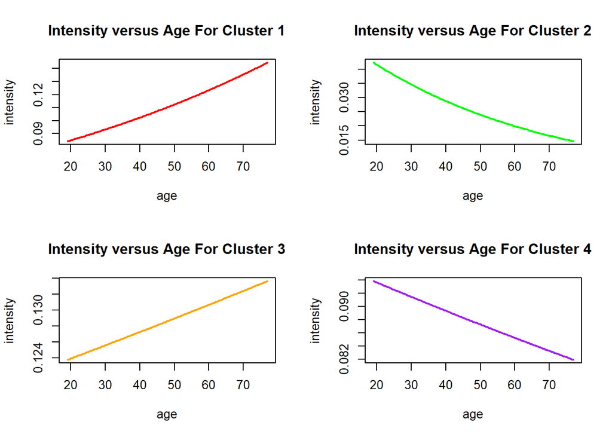

```r
par(mfrow = c(2, 2))
y_1<-predict(model_new2, list(age=xage,
                               weight=rep(1500,length(xage)),
                               distance=rep(15,length(xage)),
                               carage=rep(4,length(xage)),
                               gender=rep("male",length(xage)),
                               cluster=rep("1",length(xage)),
                               exposure=rep(1,length(xage))), type="response")
plot(xage,y_1,type = "l",main = "Intensity versus Age For Cluster 1", xlab="age",ylab="intensity", col = "red",lwd = 2)

y_2<-predict(model_new2, list(age=xage,
                               weight=rep(1500,length(xage)),
                               distance=rep(15,length(xage)),
                               carage=rep(4,length(xage)),
                               gender=rep("male",length(xage)),
                               cluster=rep("2",length(xage)),
                               exposure=rep(1,length(xage))),
                               type="response")
plot(xage,y_2,type = "l",main = "Intensity versus Age For Cluster 2", xlab="age",ylab="intensity", col = "green",lwd = 2)

y_3<-predict(model_new2, list(age=xage,
                               weight=rep(1500,length(xage)),
                               distance=rep(15,length(xage)),
                               carage=rep(4,length(xage)),
                               gender=rep("male",length(xage)),
                               cluster=rep("3",length(xage)),
                               exposure=rep(1,length(xage))),
                               type="response")
plot(xage,y_3,type = "l",main = "Intensity versus Age For Cluster 3", xlab="age",ylab="intensity", col = "orange",lwd = 2)

y_4<-predict(model_new2, list(age=xage,
                               weight=rep(1500,length(xage)),
                               distance=rep(15,length(xage)),
                               carage=rep(4,length(xage)),
                               gender=rep("male",length(xage)),
                               cluster=rep("4",length(xage)),
                               exposure=rep(1,length(xage))),
                               type="response")
plot(xage,y_4,type = "l",main = "Intensity versus Age For Cluster 4", xlab="age",ylab="intensity", col = "purple",lwd = 2)
```

Question e)

Fit a Poisson Regression Tree without x6

```r
Reg_T<- rpart(cbind(exposure,Counts)~
                            weight+distance+age+carage+gender,
                            data=Assg,
                            method="poisson")
```

Find the optimal cp

```r
cp.select <- function(tree){
  min.x <- which.min(tree$cp[, 4])
  for(i in 1:nrow(tree$cp)){
    if(tree$cp[i, 4] < tree$cp[min.x, 4]
       + tree$cp[min.x, 5]){
      return(tree$cp[i, 1])
    }
  }
}
cp.best <-cp.select(Reg_T)
cp.best
```

```
## [1] 0.01
```

Prune and Plot - The optimal size of tree is 2 with 3 leaves

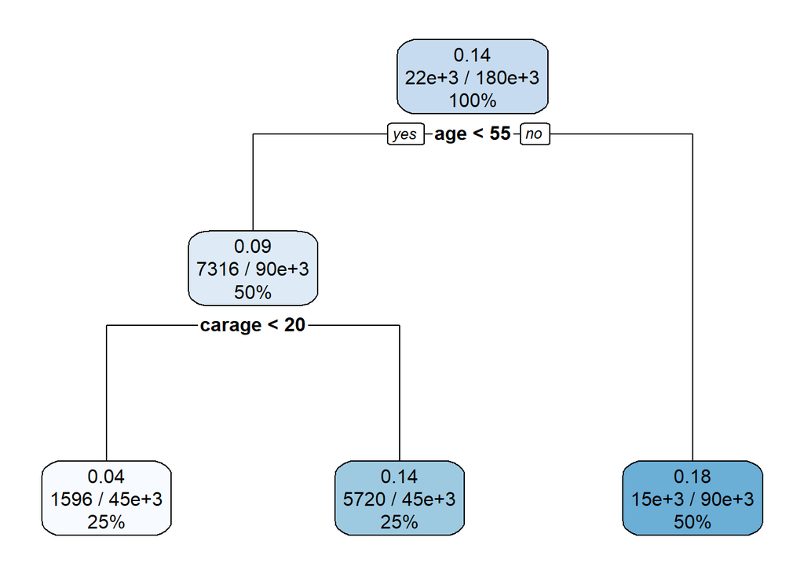

```r
prune <- prune(Reg_T, cp=cp.best)
rpart.plot(prune)
```

As a benchmark, λ = 0.0395817

```r
lambda_Prune <- predict(prune,list(weight = 1500, distance = 15, age = 25, carage = 4, gender ="male",exposure = 1), type = "vector")
lambda_Prune
```

```
##         1
## 0.0395817
```

Plot λ versus x3 (age), exposure = 1

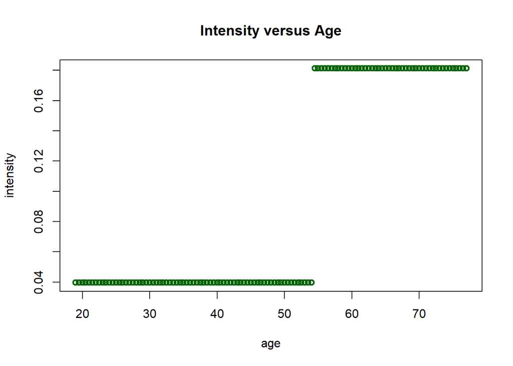

```r
xage<-seq(min(Assg$age),max(Assg$age),0.5)
y_prune<-predict(prune,list(age=xage,
                               weight=rep(1500,length(xage)),
                               distance=rep(15,length(xage)),
                               carage=rep(4,length(xage)),
                               gender=rep("male",length(xage)),
                               exposure=rep(1,length(xage)),
                               type ="vector"))
plot(xage,y_prune,main = "Intensity versus Age", xlab="age",ylab="intensity", col = "darkgreen",lwd = 2)
```

Question f)

Split 90% into train dataset, 10% is validation dataset

```r
set.seed(10)
split <- sample(c(1:nrow(Assg)),0.9 * nrow(Assg), replace = FALSE)
train <- Assg[split, ]
val <- Assg[-split, ]
```

Initialize λ(1) = 1, first I define a potential range for K - no of boosting step, max_depth - size of tree, shrinkage - shrinkage parameter.

```r
train$fit <- train$exposure
val$fit <- val$exposure
K_set <- seq(20, 50, by = 10)
max_depth_set <- 1:5
shrinkage_set <- seq(0.1, 0.5, by = 0.1)
```

Tuning hyperparameters via gridsearch

```r
set.seed(10)
# Define hyperparameter grid
grid <- expand.grid(K = K_set,
                    max_depth = max_depth_set,
                    shrinkage = shrinkage_set)

# Fit the model
fit_model <- function(K, max_depth, shrinkage) {

  # Reset fit values to initial exposure before each fit for tuning
  val$fit <- val$exposure

  for (k in 1:K) {
    boosting_step <- rpart(cbind(fit, Counts) ~ weight + distance + carage + age + gender,
                           data = train,
                           method = "poisson",
                           control = rpart.control(maxsurrogate = 0, maxdepth = max_depth,
                                                   xval = 1, cp = 0.00001, minbucket = 10000))

    val$fit <- val$fit * (predict(boosting_step, newdata = val))^shrinkage
  }

  # Calculate validation error
  val_error <- 2 * (sum(log((val$Counts / val$fit)^val$Counts)) - sum(val$Counts) + sum(val$fit)) / nrow(val)
  return(val_error)
}

# Initialize best values
best_val_error <- Inf
best_params <- list()

# Tune hyperparameters
for (i in 1:nrow(grid)) {
  val_error <- fit_model(grid$K[i], grid$max_depth[i], grid$shrinkage[i])

  # Choose the min val error and the corresponding parameters
  if (val_error < best_val_error) {
    best_val_error <- val_error
    best_params <- grid[i, ]
  }
}

best_params
```

```
##    K max_depth shrinkage
## 9 20         3       0.1
```

As benchmark, predict λ = 0.001212091

```r
set.seed(10)
benchmark <- data.frame(weight = 1500,
                        distance = 15,
                        age = 25,
                        carage = 4,
                        gender = "male",
                        exposure = 1)
benchmark$fit <- benchmark$exposure

for (k in 1:best_params$K) {
  boost_Reg <- rpart(cbind(fit, Counts) ~ weight + distance + carage + age + gender,
                         data = train,
                         method = "poisson",
                         control = rpart.control(maxsurrogate = 0, maxdepth = best_params$max_depth, xval = 1,
                                                 cp = 0.00001,
                                                 minbucket = 10000))
  benchmark$fit<- benchmark$fit*(predict(boost_Reg,newdata=benchmark))^best_params$shrinkage
}
benchmark$fit
```

```
## [1] 0.001212091
```

Plot λ vs x3 (age)

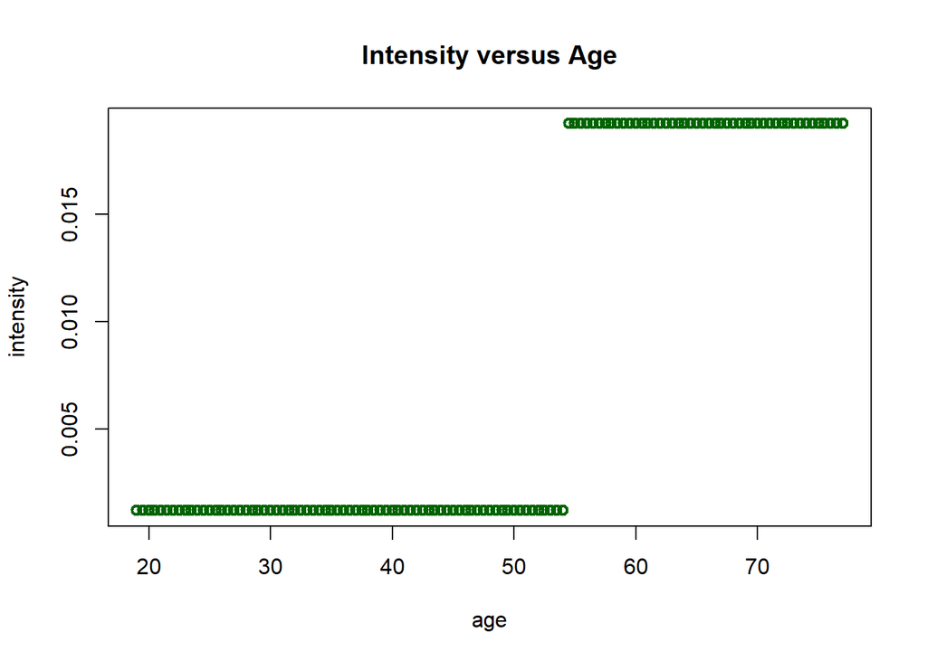

```r
set.seed(10)
plot <-  data.frame(
  age = xage,
  weight = rep(1500, length(xage)),
  distance = rep(15, length(xage)),
  carage = rep(4, length(xage)),
  gender = rep("male", length(xage)),
  exposure = rep(1, length(xage))
)

plot$fit <- plot$exposure

for (k in 1:best_params$K) {
  boost_Reg <- rpart(cbind(fit, Counts) ~ weight + distance + carage + age + gender,
                         data = train,
                         method = "poisson",
                         control = rpart.control(maxsurrogate = 0, maxdepth = best_params$max_depth, xval = 1,
                                                 cp = 0.00001,
                                                 minbucket = 10000))
plot$fit<- plot$fit*(predict(boost_Reg,newdata=plot))^best_params$shrinkage
}

plot(xage,plot$fit,main = "Intensity versus Age", xlab="age",ylab="intensity", col = "darkgreen",lwd = 2)
```

Question g)

Since base model is GLM in b), λ(1) is from the best model fitted in b)

```r
train$fit_GLM <- train$exposure*predict(model_new, newdata = train, type = "response")
val$fit_GLM <- val$exposure*predict(model_new, newdata = val, type = "response")
```

Tuning hyperparameters via gridsearch

```r
set.seed(10)
# Fit the model
fit_GLM_model <- function(K, max_depth, shrinkage) {

  # Reset fit values to initial exposure before each fit
  val$fit_GLM <- val$fit_GLM

  for (k in 1:K) {
    boosting_step <- rpart(cbind(fit_GLM, Counts) ~ weight + distance + carage + age + gender,
                           data = train,
                           method = "poisson",
                           control = rpart.control(maxsurrogate = 0, maxdepth = max_depth,
                                                   xval = 1, cp = 0.00001, minbucket = 10000))

val$fit_GLM <- val$fit_GLM*(predict(boosting_step, newdata = val))^shrinkage
  }

  # Calculate validation error
  val_error_GLM <- 2 * (sum(log((val$Counts / val$fit_GLM)^val$Counts)) - sum(val$Counts) + sum(val$fit_GLM)) / nrow(val)
  return(val_error_GLM)
}

# Initialize best values
best_val_error_GLM <- Inf
best_params_GLM <- list()

# Tune hyperparameters
for (i in 1:nrow(grid)) {
  val_error_GLM <- fit_model(grid$K[i], grid$max_depth[i], grid$shrinkage[i])

  # Update best parameters if current error is lower
  if (val_error_GLM < best_val_error_GLM) {
    best_val_error_GLM <- val_error_GLM
    best_params_GLM <- grid[i, ]
  }
}

best_params_GLM
```

```
##    K max_depth shrinkage
## 9 20         3       0.1
```

As benchmark, predict λ = 2.080405e-05

```r
set.seed(10)
benchmark$fit_GLM <- benchmark$exposure*predict(model_new, newdata = benchmark, type = "response")

for (k in 1:best_params_GLM$K) {
  boost_Reg_GLM <- rpart(cbind(fit, Counts) ~ weight + distance + carage + age + gender,
                         data = train,
                         method = "poisson",
                         control = rpart.control(maxsurrogate = 0, maxdepth = best_params_GLM$max_depth, xval = 1,
                                                 cp = 0.00001,
                                                 minbucket = 10000))
  benchmark$fit_GLM<- benchmark$fit_GLM*(predict(boost_Reg_GLM,newdata=benchmark))^best_params_GLM$shrinkage
}
benchmark$fit_GLM
```

```
## [1] 2.080405e-05
```

Plot λ vs x3 (age)

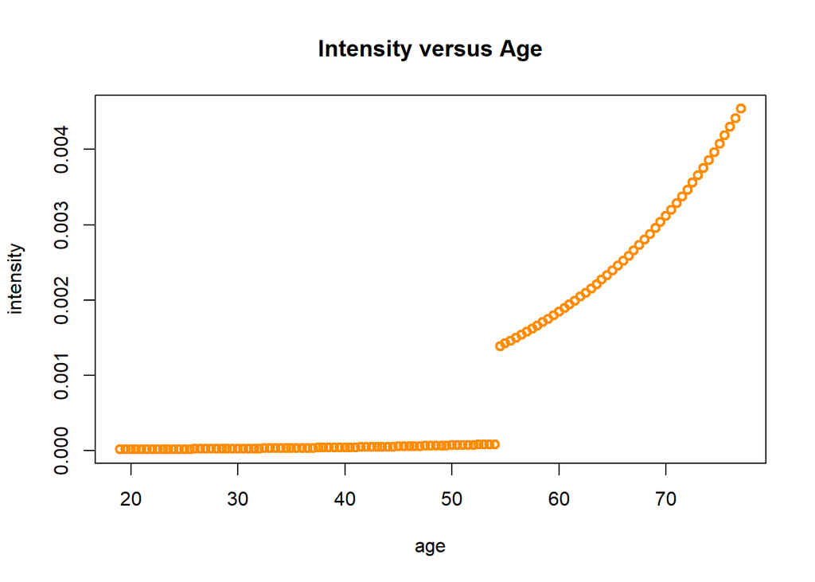

```r
set.seed(10)

# Lambda (1) is predicted by best model in b) based on the plot dataframe

plot$fit_GLM <- plot$exposure*predict(model_new, newdata = plot, type = "response")

for (k in 1:best_params_GLM$K) {
  boost_Reg_GLM <- rpart(cbind(fit, Counts) ~ weight + distance + carage + age + gender,
                         data = train,
                         method = "poisson",
                         control = rpart.control(maxsurrogate = 0, maxdepth = best_params_GLM$max_depth, xval = 1,
                                                 cp = 0.00001,
                                                 minbucket = 10000))
plot$fit_GLM<- plot$fit_GLM*(predict(boost_Reg_GLM,newdata=plot))^best_params_GLM$shrinkage
}

plot(xage,plot$fit_GLM,main = "Intensity versus Age", xlab="age",ylab="intensity", col = "darkorange",lwd = 2)
```

Question h)

Set up for 10 K-fold CV

```r
set.seed(10)
# Make new dataset to avoid changing in the original dataset
Assg1 <- Assg
Assg1$random <- runif(nrow(Assg1))
Assg1 <- Assg1[order(Assg1$random),]

K <- 10
Assg1$CV <- rep(1:K, length = nrow(Assg1))
```

For b) CV error = 0.05117425

```r
set.seed(10)
val_error <- 0
for (k in 1:K) {
  Assg1.train <- Assg1[Assg1$CV != k, ]
  Assg1.val <- Assg1[Assg1$CV == k, ]

  predictions <- predict(model_new, newdata = Assg1.val, type = "response")

  # Calculate validation error using the specified metric
  val_error <- 2 * (sum(log((Assg1.val$Counts / predictions)^Assg1.val$Counts)) -   sum(Assg1.val$Counts) + sum(predictions)) / nrow(Assg1.val)
}

# CV error
val_error/K
```

```
## [1] 0.05117425
```

For d) CV error = 0.05093664

```r
set.seed(10)
val_error <- 0
for (k in 1:K) {
  Assg1.val <- Assg1[Assg1$CV == k, ]
  # Predict on new dataset
  predictions <- predict(model_new2, newdata = Assg1.val, type = "response")
  # Calculate validation error
  val_error <- 2 * (sum(log((Assg1.val$Counts / predictions)^Assg1.val$Counts)) -   sum(Assg1.val$Counts) + sum(predictions)) / nrow(Assg1.val)
}

# CV error
val_error/K
```

```
## [1] 0.05093664
```

For e) CV error = 0.0513968

```r
set.seed(10)
val_error <- 0

for (k in 1:K) {
  Assg1.val <- Assg1[Assg1$CV == k, ]
  # Predict the best model in e) on new validation dataset
  predictions <- predict(prune, newdata = Assg1.val, type = "vector")
  # Calculate validation error
  val_error <- 2 * (sum(log((Assg1.val$Counts / predictions)^Assg1.val$Counts)) -  sum(Assg1.val$Counts) + sum(predictions)) / nrow(Assg1.val)
}

# CV error
val_error/K
```

```
## [1] 0.0513968
```

For f) CV error = 0.07586909

```r
set.seed(10)
for (k in 1:10) {
  Assg1.val <- Assg1[Assg1$CV == k, ]

  #The initial is same when doing tuning parameters
  Assg1.val$fit <- Assg1.val$exposure

  # Boosting loop, use the fitted model in f) so data is still "train"
  for (i in 1:best_params$K) {
    boosting_step <- rpart(cbind(fit, Counts) ~ weight + distance + carage + age + gender,
                           data = train,
                           method = "poisson",
                           control = rpart.control(maxsurrogate = 0, maxdepth = best_params$max_depth,   xval = 1, cp = 0.00001, minbucket = 10000))

    # Predict the best model in f) in new test set Assg1.val

    Assg1.val$fit <- Assg1.val$fit * (predict(boosting_step, newdata = Assg1.val))^best_params$shrinkage
  }
  # Calculate validation error of f) in new test set Assg1.val
  val_error <- 2 * (sum(log((Assg1.val$Counts / Assg1.val$fit)^Assg1.val$Counts)) - sum(Assg1.val$Counts) + sum(Assg1.val$fit)) / nrow(Assg1.val)
}

#CV error
val_error/K
```

```
## [1] 0.07586909
```

For g) CV error = 0.05148029

```r
set.seed(10)
for (k in 1:10) {
    Assg1.train <- Assg1[Assg1$CV != k, ]
    Assg1.val <- Assg1[Assg1$CV == k, ]

    #The initial is same when doing tuning parameters
    Assg1.val$fit_GLM <- Assg1.val$exposure*predict(model_new, newdata = Assg1.val, type = "response")

  # Boosting loop, use the fitted model in g) so data is still "train"
  for (i in 1:best_params_GLM$K) {
    boosting_step <- rpart(cbind(fit_GLM, Counts) ~ weight + distance + carage + age + gender,
                           data = train,
                           method = "poisson",
                           control = rpart.control(maxsurrogate = 0, maxdepth = best_params_GLM$max_depth,
                                                   xval = 1, cp = 0.00001, minbucket = 10000))

    #Predict the best model in g) in new test set Assg1.val

    Assg1.val$fit_GLM <- Assg1.val$fit_GLM * (predict(boosting_step, newdata = Assg1.val))^best_params_GLM$shrinkage
  }

  # Calculate validation error g) the new test set Assg1.val
  val_error <- 2 * (sum(log((Assg1.val$Counts / Assg1.val$fit_GLM)^Assg1.val$Counts)) - sum(Assg1.val$Counts) + sum(Assg1.val$fit_GLM)) / nrow(Assg1.val)
}

 #CV error
val_error/K
```

```
## [1] 0.05148029
```